# CuedEmotion

Gabriel

9/30/2017

## Participants

| Age | Mean | SD | N |
| --- | --- | --- | --- |
| 6-7 months | 187.87 | 12.29 | 15 |
| 8-9 months | 266.75 | 19.73 | 16 |

## Initial look latency

I analyzed the time participants needed to look at the emotional faces between the congruent and incongruent conditions. If the emotional sounds enabled infants to find the corresponding emotional faces, they should show shorter latency to find the face with congruent expression than those with incongruent expression, that is the cueing effect.

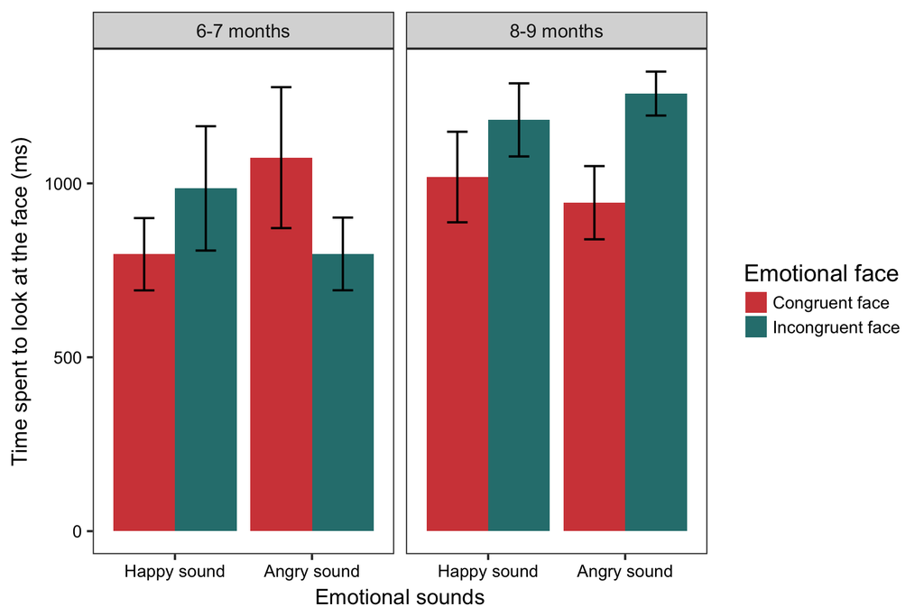

The results showed that 6-7 months old infants did not show consistent cuing effect. They showed a bias towards happy faces regardless of the emotional sounds. When happy sound was played, they showed faster looking to happy faces than to angry faces. However, when angry sound was played, they also looked at the happy faces faster than the angry faces.

As for the 8-9 months old infants, they exhibited consistent faster looking to the corresponding emotional faces, indicating the emotional sound facilitated infants’ looking to the emotional faces at 8-9 months of age.

**An ANOVA with congruency and emotional cues as IVs and initial look lentancy as the dependent variable showed a significant main effect of congruency in 8-9 months old infants. No other significant effect was found.**

## Proportional look over time

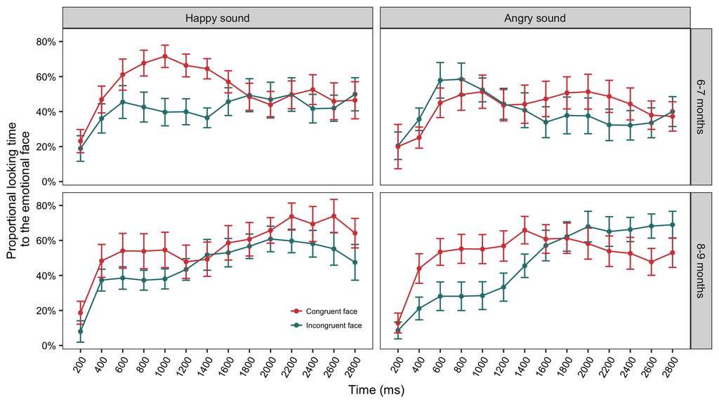

By examining the time related change in the proportional looking to emotional faces, we found that the proportion 8-9 months old infants looked at the congruent faces was higher than that of incongruent faces. This congruency effect emerged around 200 ms to 1400 ms after the onset of face images.

Six-7 months old infants, only showed higher proportional looking in the happy sound condition, but not the angry sound condition. This biased is likely caused by a visual preference for happy faces over the paired neutral faces, as indicated in the results of initial face looking latency.

## Cumulative proportional look

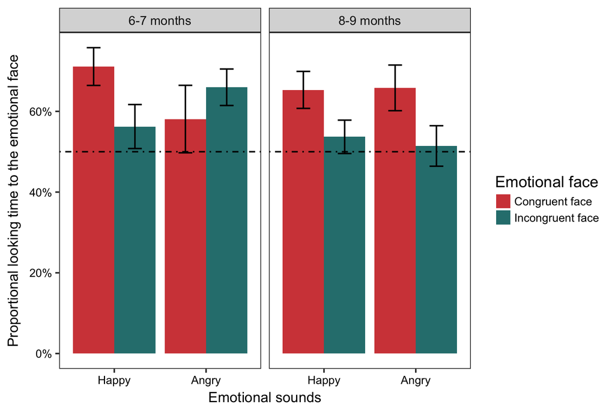

The results of cumulative proportional looking were consistent with the results of the time-related change in the proportional looking over time. Moreover, it showed that 8-9 months old infants looked at the corresponding emotional faces significantly above chance (50%) in both emotional sound conditions. The proportional looking time to the emotional faces in the incongruent conditions were not significantly different from chance.

**An ANOVA with congruency and emotional cues as IVs and look proportion as the dependent variable showed a significant main effect of congruency in 8-9 months old infants. No other significant effect was found. One-sample t-test also confirmed the proportional looking in the congruent conditions were significantly above chance. The proportional looking time was not significantly different from the chance in the incongruent conditions.**

Six-7 months old infants, again showed a bias of looking at happy faces regardless of the emotional sound.

## Conclusions

The results showed that infants at 8 to 9 months of age can use the knowledge of the correspondence between emotional voices and emotional facial expressions to guide their attention (visual search) when hearing happy or angry voices. This ability was not revealed in younger infants around 6 to 7 months of age.

**By increasing the sample size from 13 to 16, we confirmed the effect of confruency in initial look lantency and proportional look. These results suggest that infants at 8-9 months of age were able to use emotional voices to guide their visual attention to corresponding emotional faces.**

## Discussion

This age-related difference is very interesting, which might indicate a development in using knowledge to guide visual perception in infancy. Moreover, the mechanism underlying this development maybe related to a suppression of spontaneous visual preference. Specifically, younger infants’ visual perception may be largely driven by bottom up information, while the top-down information were relatively weak in guiding visual perception (attention). On the contrary, older infants are able to use the top-down information in guiding their attention by suppressing a spontaneous visual preference (if it exists).

Considering the finding of Spelke (1981?), the ability to use top-down information may be also developed from a specific association between a particular sound and a particular visual feature to general associations a category of sound with a category of visual features.